# Lab1 Project

# Coronavirus Analysis

(This project study about covid, which is one of the most infectious viruses in history)

**Member lists**

| Full Name | MSSV | Tasks | Contribution |
| --- | --- | --- | --- |
| Lâm Thị Xuân Thy | 20127082 | Preprocessing continents dataset | 100% |
| Nguyễn Huy Hoàn | 20127166 | Preprocessing countries dataset | 100% |
| Bùi Thanh Lâm | 20127402 | Question 1: Which countries have had high newcases recently and find the reason. | 100% |
| Đào Ngọc Hoa | 20127500 | I. Data Colection, II. Read data and preprocessing | 100% |
| Võ Thanh Lâm | 20127546 | Question 2: What are the current trends of covid pandemic among continents? | 100% |

## II. Data Exploration

(*This process is often interleaved with preprocessing*)

**Import libraries**

```python
import pandas as pd
import glob
import seaborn as sns
import matplotlib.pyplot as plt
from pandas.plotting import parallel_coordinates
```

**Read data**

```python
csv_files = glob.glob("Date*.csv")
csv_files
```

```
['Date2023-02-25.csv',
 'Date2023-03-09.csv',
 'Date2023-03-10.csv',
 'Date2023-03-06.csv',
 'Date2023-02-24.csv',
 'Date2023-03-05.csv',
 'Date2023-02-28.csv',
 'Date2023-03-04.csv',
 'Date2023-02-27.csv',
 'Date2023-03-07.csv',
 'Date2023-03-08.csv',
 'Date2023-02-26.csv',
 'Date2023-03-02.csv',
 'Date2023-03-11.csv',
 'Date2023-03-01.csv',
 'Date2023-03-03.csv']
```

```python
df_list = (pd.read_csv(file) for file in csv_files)
```

```python
big_df = pd.read_csv('Date2023-02-27.csv')
```

```python
big_df.head()
```

|  | # | Country,Other | TotalCases | NewCases | TotalDeaths | NewDeaths | TotalRecovered | NewRecovered | ActiveCases | Serious,Critical | ... | Tests/\n1M pop\n | Population | Continent | 1 Caseevery X ppl | 1 Deathevery X ppl | 1 Testevery X ppl | New Cases/1M pop | New Deaths/1M pop | Active Cases/1M pop | Date |
| --- | --- | --- | --- | --- | --- | --- | --- | --- | --- | --- | --- | --- | --- | --- | --- | --- | --- | --- | --- | --- | --- |
| 0 | NaN | \nAsia\n | 214,275,435 | +21,169 | 1,536,461 | 157.0 | 198,909,142 | +28,708 | 13,829,832 | 15,497 | ... | NaN | NaN | Asia | \n | NaN | NaN | NaN | NaN | NaN | 2023-02-27 |
| 1 | NaN | \nNorth America\n | 124,580,169 | +16,947 | 1,611,268 | 149.0 | 119,787,772 | +43,175 | 3,181,129 | 7,750 | ... | NaN | NaN | North America | \n | NaN | NaN | NaN | NaN | NaN | 2023-02-27 |
| 2 | NaN | \nEurope\n | 246,227,059 | +55,613 | 2,016,755 | 297.0 | 241,811,330 | +45,101 | 2,398,974 | 6,459 | ... | NaN | NaN | Europe | \n | NaN | NaN | NaN | NaN | NaN | 2023-02-27 |
| 3 | NaN | \nSouth America\n | 67,991,811 | +15,796 | 1,350,520 | 92.0 | 66,251,241 | +38,668 | 390,050 | 10,186 | ... | NaN | NaN | South America | \n | NaN | NaN | NaN | NaN | NaN | 2023-02-27 |
| 4 | NaN | \nOceania\n | 13,996,291 | +1,297 | 26,116 | 6.0 | 13,834,558 | +1,186 | 135,617 | 64 | ... | NaN | NaN | Australia/Oceania | \n | NaN | NaN | NaN | NaN | NaN | 2023-02-27 |

5 rows × 23 columns

**The number of rows and columns**

```python
rows, cols = big_df.shape
rows, cols
```

```
(247, 23)
```

[output not shown]

```python
big_df.info()
```

```
<class 'pandas.core.frame.DataFrame'>
RangeIndex: 247 entries, 0 to 246
Data columns (total 23 columns):
 #   Column               Non-Null Count  Dtype
---  ------               --------------  -----
 0   #                    231 non-null    float64
 1   Country,Other        247 non-null    object
 2   TotalCases           247 non-null    object
 3   NewCases             94 non-null     object
 4   TotalDeaths          247 non-null    object
 5   NewDeaths            49 non-null     float64
 6   TotalRecovered       226 non-null    object
 7   NewRecovered         82 non-null     object
 8   ActiveCases          228 non-null    object
 9   Serious,Critical     141 non-null    object
```

[output cut: 17 more lines]

*There are some columns having inappropriate data types.*

### Preprocessing

**Convert object to numeric datatypes**

```python
columns = ['TotalCases', 'NewCases', 'TotalDeaths',\
       'TotalRecovered', 'NewRecovered', 'ActiveCases',\
       'Serious,Critical', 'Tot\xa0Cases/1M pop', 'Deaths/1M pop', 'TotalTests',\
       'Tests/\n1M pop\n', 'Population', '1 Caseevery X ppl',\
       '1 Deathevery X ppl', 'New Cases/1M pop', 'Active Cases/1M pop']
```

```python
big_df[columns] = big_df[columns].astype(str).apply(lambda x: pd.to_numeric(x.str.replace('\D','',regex=True)))
```

```python
big_df.describe()
```

|  | # | TotalCases | NewCases | TotalDeaths | NewDeaths | TotalRecovered | NewRecovered | ActiveCases | Serious,Critical | Tot Cases/1M pop | Deaths/1M pop | TotalTests | Tests/\n1M pop\n | Population | 1 Caseevery X ppl | 1 Deathevery X ppl | 1 Testevery X ppl | New Cases/1M pop | New Deaths/1M pop | Active Cases/1M pop |
| --- | --- | --- | --- | --- | --- | --- | --- | --- | --- | --- | --- | --- | --- | --- | --- | --- | --- | --- | --- | --- |
| count | 231.000000 | 2.470000e+02 | 94.000000 | 2.410000e+02 | 49.000000 | 2.260000e+02 | 82.000000 | 2.280000e+02 | 141.000000 | 231.000000 | 225.000000 | 2.130000e+02 | 2.130000e+02 | 2.290000e+02 | 229.000000 | 223.000000 | 213.000000 | 80.000000 | 34.000000 | 219.000000 |
| mean | 116.000000 | 1.376245e+07 | 5971.968085 | 1.410729e+05 | 71.938776 | 1.435566e+07 | 9592.951220 | 4.403410e+05 | 1272.170213 | 198060.584416 | 1311.728889 | 3.259416e+07 | 2.125101e+06 | 3.469404e+07 | 404.218341 | 14465.672646 | 10.727700 | 512.050000 | 0.820000 | 28792.305936 |
| std | 66.828138 | 6.851378e+07 | 18450.358802 | 6.838457e+05 | 149.259200 | 6.866470e+07 | 26657.871441 | 2.427947e+06 | 5352.664904 | 201127.441547 | 1453.499687 | 1.181992e+08 | 3.626734e+06 | 1.386374e+08 | 4147.122732 | 57220.935490 | 26.759076 | 1000.874262 | 1.214264 | 92043.329482 |
| min | 1.000000 | 5.000000e+00 | 1.000000 | 1.000000e+00 | 1.000000 | 2.000000e+00 | 1.000000 | 0.000000e+00 | 0.000000 | 16.000000 | 2.000000 | 7.850000e+03 | 5.091000e+03 | 7.990000e+02 | 1.000000 | 154.000000 | 0.000000 | 1.000000 | 0.010000 | 1.000000 |
| 25% | 58.500000 | 2.634950e+04 | 17.500000 | 2.270000e+02 | 3.000000 | 2.345850e+04 | 25.000000 | 5.450000e+01 | 5.000000 | 17414.500000 | 175.000000 | 3.478150e+05 | 1.899430e+05 | 4.454310e+05 | 3.000000 | 500.000000 | 0.000000 | 7.000000 | 0.200000 | 58.000000 |
| 50% | 116.000000 | 2.509320e+05 | 124.500000 | 2.804000e+03 | 11.000000 | 3.079295e+05 | 204.500000 | 1.253500e+03 | 18.000000 | 124608.000000 | 818.000000 | 2.226216e+06 | 8.851190e+05 | 5.797805e+06 | 8.000000 | 1255.000000 | 1.000000 | 70.000000 | 0.400000 | 554.000000 |
| 75% | 173.500000 | 1.950276e+06 | 1330.000000 | 1.987000e+04 | 59.000000 | 2.380961e+06 | 2603.750000 | 1.367650e+04 | 74.000000 | 321429.000000 | 2060.000000 | 1.302420e+07 | 2.439107e+06 | 2.210284e+07 | 58.000000 | 5911.000000 | 5.000000 | 580.000000 | 0.700000 | 3582.500000 |
| max | 231.000000 | 6.798651e+08 | 112273.000000 | 6.799716e+06 | 705.000000 | 6.526698e+08 | 157321.000000 | 2.039560e+07 | 40503.000000 | 872204.000000 | 8723.000000 | 1.166806e+09 | 2.330212e+07 | 1.448471e+09 | 62616.000000 | 626161.000000 | 196.000000 | 4790.000000 | 5.000000 | 611101.000000 |

**Convert `Date` to datatime type**

```python
big_df['Date'] = pd.to_datetime(big_df['Date']).dt.date
```

# Countries

```python
countries_df = big_df.dropna(subset=['#'])
countries_df.head()
```

|  | # | Country,Other | TotalCases | NewCases | TotalDeaths | NewDeaths | TotalRecovered | NewRecovered | ActiveCases | Serious,Critical | ... | Tests/\n1M pop\n | Population | Continent | 1 Caseevery X ppl | 1 Deathevery X ppl | 1 Testevery X ppl | New Cases/1M pop | New Deaths/1M pop | Active Cases/1M pop | Date |
| --- | --- | --- | --- | --- | --- | --- | --- | --- | --- | --- | --- | --- | --- | --- | --- | --- | --- | --- | --- | --- | --- |
| 8 | 1.0 | China | 503302 | NaN | 5272.0 | NaN | 379053.0 | NaN | 118977.0 | 7557.0 | ... | 110461.0 | 1.448471e+09 | Asia | 2878.0 | 274748.0 | 9.0 | NaN | NaN | 82.0 | 2023-02-27 |
| 9 | 2.0 | USA | 105276823 | 6894.0 | 1145556.0 | 70.0 | 102654350.0 | 33706.0 | 1476917.0 | 2586.0 | ... | 3485028.0 | 3.348053e+08 | North America | 3.0 | 292.0 | 0.0 | 210.0 | 0.2 | 4411.0 | 2023-02-27 |
| 10 | 3.0 | India | 44686371 | 169.0 | 530771.0 | 1.0 | 44153343.0 | 140.0 | 2257.0 | NaN | ... | 653003.0 | 1.406632e+09 | Asia | 31.0 | 2650.0 | 2.0 | 1.0 | NaN | 2.0 | 2023-02-27 |
| 11 | 4.0 | France | 39616580 | 841.0 | 164929.0 | 52.0 | 39383240.0 | 4999.0 | 68411.0 | 869.0 | ... | 4139547.0 | 6.558452e+07 | Europe | 2.0 | 398.0 | 0.0 | 130.0 | 0.8 | 1043.0 | 2023-02-27 |
| 12 | 5.0 | Germany | 38144033 | 32970.0 | 167951.0 | 139.0 | 37679400.0 | 17900.0 | 296682.0 | NaN | ... | 1458359.0 | 8.388360e+07 | Europe | 2.0 | 499.0 | 1.0 | 3930.0 | 2.0 | 3537.0 | 2023-02-27 |

5 rows × 23 columns

**Values distribution of Numeric columns**

```python
df = countries_df.describe().T
df['missing_percentage'] = ((1-df['count']/len(countries_df)) * 100).round(1)
df
```

|  | count | mean | std | min | 25% | 50% | 75% | max | missing_percentage |
| --- | --- | --- | --- | --- | --- | --- | --- | --- | --- |
| # | 231.0 | 1.160000e+02 | 6.682814e+01 | 1.00 | 58.50 | 116.0 | 173.50 | 2.310000e+02 | 0.0 |
| TotalCases | 231.0 | 2.943139e+06 | 9.559476e+06 | 5.00 | 24123.00 | 206633.0 | 1300452.50 | 1.052768e+08 | 0.0 |
| NewCases | 80.0 | 1.403412e+03 | 4.328637e+03 | 1.00 | 11.50 | 97.0 | 493.75 | 3.297000e+04 | 65.4 |
| TotalDeaths | 225.0 | 3.022096e+04 | 1.061084e+05 | 1.00 | 225.00 | 2179.0 | 14452.00 | 1.145556e+06 | 2.6 |
| NewDeaths | 35.0 | 2.014286e+01 | 2.846168e+01 | 1.00 | 2.50 | 6.0 | 28.00 | 1.390000e+02 | 84.8 |
| TotalRecovered | 210.0 | 3.017621e+06 | 9.614638e+06 | 2.00 | 21972.50 | 235145.5 | 1467827.75 | 1.026544e+08 | 9.1 |
| NewRecovered | 68.0 | 2.313794e+03 | 6.471323e+03 | 1.00 | 15.00 | 125.0 | 801.00 | 3.370600e+04 | 70.6 |
| ActiveCases | 212.0 | 8.875175e+04 | 7.959752e+05 | 0.00 | 52.25 | 1041.5 | 9963.00 | 1.143434e+07 | 8.2 |
| Serious,Critical | 125.0 | 1.389120e+02 | 7.181380e+02 | 1.00 | 4.00 | 13.0 | 52.00 | 7.557000e+03 | 45.9 |
| Tot Cases/1M pop | 229.0 | 1.956007e+05 | 1.968600e+05 | 16.00 | 17214.00 | 124608.0 | 314442.00 | 7.039590e+05 | 0.9 |
| Deaths/1M pop | 223.0 | 1.245260e+03 | 1.277662e+03 | 2.00 | 169.00 | 797.0 | 1999.00 | 6.514000e+03 | 3.5 |
| TotalTests | 213.0 | 3.259416e+07 | 1.181992e+08 | 7850.00 | 347815.00 | 2226216.0 | 13024205.00 | 1.166806e+09 | 7.8 |
| Tests/\n1M pop\n | 213.0 | 2.125101e+06 | 3.626734e+06 | 5091.00 | 189943.00 | 885119.0 | 2439107.00 | 2.330212e+07 | 7.8 |
| Population | 229.0 | 3.469404e+07 | 1.386374e+08 | 799.00 | 445431.00 | 5797805.0 | 22102838.00 | 1.448471e+09 | 0.9 |
| 1 Caseevery X ppl | 229.0 | 4.042183e+02 | 4.147123e+03 | 1.00 | 3.00 | 8.0 | 58.00 | 6.261600e+04 | 0.9 |
| 1 Deathevery X ppl | 223.0 | 1.446567e+04 | 5.722094e+04 | 154.00 | 500.00 | 1255.0 | 5911.00 | 6.261610e+05 | 3.5 |
| 1 Testevery X ppl | 213.0 | 1.072770e+01 | 2.675908e+01 | 0.00 | 0.00 | 1.0 | 5.00 | 1.960000e+02 | 7.8 |
| New Cases/1M pop | 80.0 | 5.120500e+02 | 1.000874e+03 | 1.00 | 7.00 | 70.0 | 580.00 | 4.790000e+03 | 65.4 |
| New Deaths/1M pop | 34.0 | 8.200000e-01 | 1.214264e+00 | 0.01 | 0.20 | 0.4 | 0.70 | 5.000000e+00 | 85.3 |
| Active Cases/1M pop | 219.0 | 2.879231e+04 | 9.204333e+04 | 1.00 | 58.00 | 554.0 | 3582.50 | 6.111010e+05 | 5.2 |

**NewCases**

```python
countries_df['NewCases']=countries_df['NewCases'].fillna(0)
```

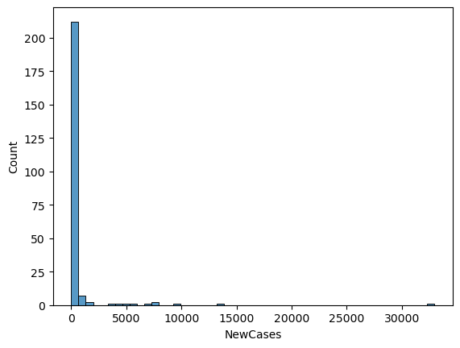

```python
sns.histplot(data=countries_df, x="NewCases",bins=50)
```

**TotalDeaths**

```python
df = countries_df.loc[countries_df['TotalDeaths'].isna()]
df
```

|  | # | Country,Other | TotalCases | NewCases | TotalDeaths | NewDeaths | TotalRecovered | NewRecovered | ActiveCases | Serious,Critical | ... | Tests/\n1M pop\n | Population | Continent | 1 Caseevery X ppl | 1 Deathevery X ppl | 1 Testevery X ppl | New Cases/1M pop | New Deaths/1M pop | Active Cases/1M pop | Date |
| --- | --- | --- | --- | --- | --- | --- | --- | --- | --- | --- | --- | --- | --- | --- | --- | --- | --- | --- | --- | --- | --- |
| 229 | 222.0 | Tuvalu | 2805 | 0.0 | NaN | NaN | NaN | NaN | 2805.0 | NaN | ... | NaN | 12066.0 | Australia/Oceania | 4.0 | NaN | NaN | NaN | NaN | 232471.0 | 2023-02-27 |
| 230 | 223.0 | Saint Helena | 2166 | 0.0 | NaN | NaN | 2.0 | NaN | 2164.0 | NaN | ... | NaN | 6115.0 | Africa | 3.0 | NaN | NaN | NaN | NaN | 353884.0 | 2023-02-27 |
| 231 | 224.0 | Falkland Islands | 1930 | 0.0 | NaN | NaN | 1930.0 | NaN | 0.0 | NaN | ... | 2439107.0 | 3539.0 | South America | 2.0 | NaN | 0.0 | NaN | NaN | NaN | 2023-02-27 |
| 233 | 226.0 | Niue | 788 | 0.0 | NaN | NaN | 776.0 | 10.0 | 12.0 | NaN | ... | NaN | 1622.0 | Australia/Oceania | 2.0 | NaN | NaN | NaN | NaN | 7398.0 | 2023-02-27 |
| 235 | 228.0 | Vatican City | 29 | 0.0 | NaN | NaN | 29.0 | NaN | 0.0 | NaN | ... | NaN | 799.0 | Europe | 28.0 | NaN | NaN | NaN | NaN | NaN | 2023-02-27 |
| 238 | 231.0 | Tokelau | 5 | 0.0 | NaN | NaN | NaN | NaN | 5.0 | NaN | ... | NaN | 1378.0 | Australia/Oceania | 276.0 | NaN | NaN | NaN | NaN | 3628.0 | 2023-02-27 |

6 rows × 23 columns

```python
df['Country,Other'].unique()
```

```
array(['Tuvalu', 'Saint Helena', 'Falkland Islands', 'Niue',
       'Vatican City', 'Tokelau'], dtype=object)
```

It seem that these regions do not report the `TotalDeaths`, that is because these are small islands or city. So for further analysis, we would drop these records.

```python
countries_df = countries_df[countries_df['TotalDeaths'].isna()==False]
```

**NewDeaths**

```python
countries_df['NewDeaths']=countries_df['NewDeaths'].fillna(0)
```

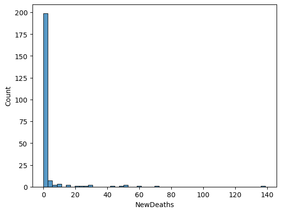

```python
sns.histplot(data=countries_df, x="NewDeaths",bins=50)
```

**TotalRecovered**

```python
df = countries_df.loc[countries_df['TotalRecovered'].isna()]
df
```

|  | # | Country,Other | TotalCases | NewCases | TotalDeaths | NewDeaths | TotalRecovered | NewRecovered | ActiveCases | Serious,Critical | ... | Tests/\n1M pop\n | Population | Continent | 1 Caseevery X ppl | 1 Deathevery X ppl | 1 Testevery X ppl | New Cases/1M pop | New Deaths/1M pop | Active Cases/1M pop | Date |
| --- | --- | --- | --- | --- | --- | --- | --- | --- | --- | --- | --- | --- | --- | --- | --- | --- | --- | --- | --- | --- | --- |
| 19 | 12.0 | Turkey | 17042722 | 0.0 | 101492.0 | 0.0 | NaN | NaN | NaN | NaN | ... | 1902052.0 | 85561976.0 | Asia | 5.0 | 843.0 | 1.0 | NaN | NaN | 1819.0 | 2023-02-27 |
| 74 | 67.0 | Tunisia | 1150793 | 0.0 | 29330.0 | 0.0 | NaN | NaN | NaN | 44.0 | ... | 415169.0 | 12046656.0 | Africa | 10.0 | 411.0 | 2.0 | NaN | NaN | 951.0 | 2023-02-27 |
| 86 | 79.0 | Paraguay | 808327 | 0.0 | 19870.0 | 0.0 | NaN | NaN | NaN | 7.0 | ... | 363751.0 | 7305843.0 | South America | 9.0 | 368.0 | 3.0 | NaN | NaN | 12338.0 | 2023-02-27 |
| 102 | 95.0 | Honduras | 472116 | 559.0 | 11111.0 | 2.0 | NaN | NaN | NaN | 105.0 | ... | 159787.0 | 10221247.0 | North America | 22.0 | 920.0 | 6.0 | 550.0 | 0.2 | 32135.0 | 2023-02-27 |
| 119 | 112.0 | Martinique | 229807 | 0.0 | 1098.0 | 0.0 | NaN | NaN | NaN | 12.0 | ... | 2215870.0 | 374087.0 | North America | 2.0 | 341.0 | 0.0 | NaN | NaN | 611101.0 | 2023-02-27 |
| 120 | 113.0 | Laos | 218015 | 0.0 | 758.0 | 0.0 | NaN | NaN | NaN | NaN | ... | 164845.0 | 7481023.0 | Asia | 34.0 | 9869.0 | 6.0 | NaN | NaN | 28017.0 | 2023-02-27 |
| 122 | 115.0 | Iceland | 208999 | 0.0 | 229.0 | 0.0 | NaN | NaN | NaN | 2.0 | ... | 5780036.0 | 345393.0 | Europe | 2.0 | 1508.0 | 0.0 | NaN | NaN | 385315.0 | 2023-02-27 |
| 124 | 117.0 | Guadeloupe | 201852 | 0.0 | 1010.0 | 0.0 | NaN | NaN | NaN | 19.0 | ... | 2346306.0 | 399794.0 | North America | 2.0 | 396.0 | 0.0 | NaN | NaN | 496736.0 | 2023-02-27 |
| 144 | 137.0 | Suriname | 82227 | 0.0 | 1400.0 | 0.0 | NaN | NaN | NaN | NaN | ... | 403644.0 | 596831.0 | South America | 7.0 | 426.0 | 2.0 | NaN | NaN | 52112.0 | 2023-02-27 |
| 146 | 139.0 | French Polynesia | 77957 | 0.0 | 649.0 | 0.0 | NaN | NaN | NaN | 7.0 | ... | NaN | 284164.0 | Australia/Oceania | 4.0 | 438.0 | NaN | NaN | NaN | 154164.0 | 2023-02-27 |
| 164 | 157.0 | Tanzania | 42823 | 0.0 | 846.0 | 0.0 | NaN | NaN | NaN | 7.0 | ... | NaN | 63298550.0 | Africa | 1478.0 | 74821.0 | NaN | NaN | NaN | 660.0 | 2023-02-27 |
| 165 | 158.0 | Mayotte | 42004 | 0.0 | 188.0 | 0.0 | NaN | NaN | NaN | NaN | ... | 618038.0 | 286259.0 | Africa | 7.0 | 1523.0 | 2.0 | NaN | NaN | 135723.0 | 2023-02-27 |
| 169 | 162.0 | Isle of Man | 38008 | 0.0 | 116.0 | 0.0 | NaN | NaN | NaN | NaN | ... | 1758422.0 | 85732.0 | Europe | 2.0 | 739.0 | 1.0 | NaN | NaN | 129450.0 | 2023-02-27 |
| 172 | 165.0 | Faeroe Islands | 34658 | 0.0 | 28.0 | 0.0 | NaN | NaN | NaN | 5.0 | ... | 15802409.0 | 49233.0 | Europe | 1.0 | 1758.0 | 0.0 | NaN | NaN | 547133.0 | 2023-02-27 |
| 180 | 173.0 | Solomon Islands | 24575 | 0.0 | 153.0 | 0.0 | NaN | NaN | NaN | 1.0 | ... | NaN | 721159.0 | Australia/Oceania | 29.0 | 4713.0 | NaN | NaN | NaN | 11183.0 | 2023-02-27 |
| 181 | 174.0 | Micronesia | 23671 | 0.0 | 60.0 | 0.0 | NaN | NaN | NaN | 1.0 | ... | 467848.0 | 117489.0 | Australia/Oceania | 5.0 | 1958.0 | 2.0 | NaN | NaN | 137834.0 | 2023-02-27 |
| 214 | 207.0 | Sierra Leone | 7760 | 0.0 | 126.0 | 0.0 | NaN | NaN | NaN | NaN | ... | 31296.0 | 8306436.0 | Africa | 1070.0 | 65924.0 | 32.0 | NaN | NaN | 330.0 | 2023-02-27 |
| 216 | 209.0 | British Virgin Islands | 7305 | 0.0 | 64.0 | 0.0 | NaN | NaN | NaN | NaN | ... | 3508269.0 | 30596.0 | North America | 4.0 | 478.0 | 0.0 | NaN | NaN | 392.0 | 2023-02-27 |
| 222 | 215.0 | St. Barth | 5439 | 0.0 | 6.0 | 0.0 | NaN | NaN | NaN | NaN | ... | 7908095.0 | 9945.0 | North America | 2.0 | 1658.0 | 0.0 | NaN | NaN | 499849.0 | 2023-02-27 |

19 rows × 23 columns

We can fill these null value by this fomula:

$$TotalRecovered=TotalCases-TotalDeaths-ActiveCases$$

However, these countries do not report ActiveCases too. Fortunately, we know `Active Cases/1M pop`, so we can find `ActiveCases` by this equation:

$$ActiveCases=Active Cases/1M pop*Population/1000000$$

**ActiveCases**

```python
countries_df.loc[countries_df['TotalRecovered'].isna(), 'ActiveCases']=round(df['Active Cases/1M pop']*df['Population']/1000000,1)
countries_df.head()
```

|  | # | Country,Other | TotalCases | NewCases | TotalDeaths | NewDeaths | TotalRecovered | NewRecovered | ActiveCases | Serious,Critical | ... | Tests/\n1M pop\n | Population | Continent | 1 Caseevery X ppl | 1 Deathevery X ppl | 1 Testevery X ppl | New Cases/1M pop | New Deaths/1M pop | Active Cases/1M pop | Date |
| --- | --- | --- | --- | --- | --- | --- | --- | --- | --- | --- | --- | --- | --- | --- | --- | --- | --- | --- | --- | --- | --- |
| 8 | 1.0 | China | 503302 | 0.0 | 5272.0 | 0.0 | 379053.0 | NaN | 118977.0 | 7557.0 | ... | 110461.0 | 1.448471e+09 | Asia | 2878.0 | 274748.0 | 9.0 | NaN | NaN | 82.0 | 2023-02-27 |
| 9 | 2.0 | USA | 105276823 | 6894.0 | 1145556.0 | 70.0 | 102654350.0 | 33706.0 | 1476917.0 | 2586.0 | ... | 3485028.0 | 3.348053e+08 | North America | 3.0 | 292.0 | 0.0 | 210.0 | 0.2 | 4411.0 | 2023-02-27 |
| 10 | 3.0 | India | 44686371 | 169.0 | 530771.0 | 1.0 | 44153343.0 | 140.0 | 2257.0 | NaN | ... | 653003.0 | 1.406632e+09 | Asia | 31.0 | 2650.0 | 2.0 | 1.0 | NaN | 2.0 | 2023-02-27 |
| 11 | 4.0 | France | 39616580 | 841.0 | 164929.0 | 52.0 | 39383240.0 | 4999.0 | 68411.0 | 869.0 | ... | 4139547.0 | 6.558452e+07 | Europe | 2.0 | 398.0 | 0.0 | 130.0 | 0.8 | 1043.0 | 2023-02-27 |
| 12 | 5.0 | Germany | 38144033 | 32970.0 | 167951.0 | 139.0 | 37679400.0 | 17900.0 | 296682.0 | NaN | ... | 1458359.0 | 8.388360e+07 | Europe | 2.0 | 499.0 | 1.0 | 3930.0 | 2.0 | 3537.0 | 2023-02-27 |

5 rows × 23 columns

```python
df = countries_df.loc[countries_df['TotalRecovered'].isna()]
df
```

|  | # | Country,Other | TotalCases | NewCases | TotalDeaths | NewDeaths | TotalRecovered | NewRecovered | ActiveCases | Serious,Critical | ... | Tests/\n1M pop\n | Population | Continent | 1 Caseevery X ppl | 1 Deathevery X ppl | 1 Testevery X ppl | New Cases/1M pop | New Deaths/1M pop | Active Cases/1M pop | Date |
| --- | --- | --- | --- | --- | --- | --- | --- | --- | --- | --- | --- | --- | --- | --- | --- | --- | --- | --- | --- | --- | --- |
| 19 | 12.0 | Turkey | 17042722 | 0.0 | 101492.0 | 0.0 | NaN | NaN | 155637.2 | NaN | ... | 1902052.0 | 85561976.0 | Asia | 5.0 | 843.0 | 1.0 | NaN | NaN | 1819.0 | 2023-02-27 |
| 74 | 67.0 | Tunisia | 1150793 | 0.0 | 29330.0 | 0.0 | NaN | NaN | 11456.4 | 44.0 | ... | 415169.0 | 12046656.0 | Africa | 10.0 | 411.0 | 2.0 | NaN | NaN | 951.0 | 2023-02-27 |
| 86 | 79.0 | Paraguay | 808327 | 0.0 | 19870.0 | 0.0 | NaN | NaN | 90139.5 | 7.0 | ... | 363751.0 | 7305843.0 | South America | 9.0 | 368.0 | 3.0 | NaN | NaN | 12338.0 | 2023-02-27 |
| 102 | 95.0 | Honduras | 472116 | 559.0 | 11111.0 | 2.0 | NaN | NaN | 328459.8 | 105.0 | ... | 159787.0 | 10221247.0 | North America | 22.0 | 920.0 | 6.0 | 550.0 | 0.2 | 32135.0 | 2023-02-27 |
| 119 | 112.0 | Martinique | 229807 | 0.0 | 1098.0 | 0.0 | NaN | NaN | 228604.9 | 12.0 | ... | 2215870.0 | 374087.0 | North America | 2.0 | 341.0 | 0.0 | NaN | NaN | 611101.0 | 2023-02-27 |
| 120 | 113.0 | Laos | 218015 | 0.0 | 758.0 | 0.0 | NaN | NaN | 209595.8 | NaN | ... | 164845.0 | 7481023.0 | Asia | 34.0 | 9869.0 | 6.0 | NaN | NaN | 28017.0 | 2023-02-27 |
| 122 | 115.0 | Iceland | 208999 | 0.0 | 229.0 | 0.0 | NaN | NaN | 133085.1 | 2.0 | ... | 5780036.0 | 345393.0 | Europe | 2.0 | 1508.0 | 0.0 | NaN | NaN | 385315.0 | 2023-02-27 |
| 124 | 117.0 | Guadeloupe | 201852 | 0.0 | 1010.0 | 0.0 | NaN | NaN | 198592.1 | 19.0 | ... | 2346306.0 | 399794.0 | North America | 2.0 | 396.0 | 0.0 | NaN | NaN | 496736.0 | 2023-02-27 |
| 144 | 137.0 | Suriname | 82227 | 0.0 | 1400.0 | 0.0 | NaN | NaN | 31102.1 | NaN | ... | 403644.0 | 596831.0 | South America | 7.0 | 426.0 | 2.0 | NaN | NaN | 52112.0 | 2023-02-27 |
| 146 | 139.0 | French Polynesia | 77957 | 0.0 | 649.0 | 0.0 | NaN | NaN | 43807.9 | 7.0 | ... | NaN | 284164.0 | Australia/Oceania | 4.0 | 438.0 | NaN | NaN | NaN | 154164.0 | 2023-02-27 |
| 164 | 157.0 | Tanzania | 42823 | 0.0 | 846.0 | 0.0 | NaN | NaN | 41777.0 | 7.0 | ... | NaN | 63298550.0 | Africa | 1478.0 | 74821.0 | NaN | NaN | NaN | 660.0 | 2023-02-27 |
| 165 | 158.0 | Mayotte | 42004 | 0.0 | 188.0 | 0.0 | NaN | NaN | 38851.9 | NaN | ... | 618038.0 | 286259.0 | Africa | 7.0 | 1523.0 | 2.0 | NaN | NaN | 135723.0 | 2023-02-27 |
| 169 | 162.0 | Isle of Man | 38008 | 0.0 | 116.0 | 0.0 | NaN | NaN | 11098.0 | NaN | ... | 1758422.0 | 85732.0 | Europe | 2.0 | 739.0 | 1.0 | NaN | NaN | 129450.0 | 2023-02-27 |
| 172 | 165.0 | Faeroe Islands | 34658 | 0.0 | 28.0 | 0.0 | NaN | NaN | 26937.0 | 5.0 | ... | 15802409.0 | 49233.0 | Europe | 1.0 | 1758.0 | 0.0 | NaN | NaN | 547133.0 | 2023-02-27 |
| 180 | 173.0 | Solomon Islands | 24575 | 0.0 | 153.0 | 0.0 | NaN | NaN | 8064.7 | 1.0 | ... | NaN | 721159.0 | Australia/Oceania | 29.0 | 4713.0 | NaN | NaN | NaN | 11183.0 | 2023-02-27 |
| 181 | 174.0 | Micronesia | 23671 | 0.0 | 60.0 | 0.0 | NaN | NaN | 16194.0 | 1.0 | ... | 467848.0 | 117489.0 | Australia/Oceania | 5.0 | 1958.0 | 2.0 | NaN | NaN | 137834.0 | 2023-02-27 |
| 214 | 207.0 | Sierra Leone | 7760 | 0.0 | 126.0 | 0.0 | NaN | NaN | 2741.1 | NaN | ... | 31296.0 | 8306436.0 | Africa | 1070.0 | 65924.0 | 32.0 | NaN | NaN | 330.0 | 2023-02-27 |
| 216 | 209.0 | British Virgin Islands | 7305 | 0.0 | 64.0 | 0.0 | NaN | NaN | 12.0 | NaN | ... | 3508269.0 | 30596.0 | North America | 4.0 | 478.0 | 0.0 | NaN | NaN | 392.0 | 2023-02-27 |
| 222 | 215.0 | St. Barth | 5439 | 0.0 | 6.0 | 0.0 | NaN | NaN | 4971.0 | NaN | ... | 7908095.0 | 9945.0 | North America | 2.0 | 1658.0 | 0.0 | NaN | NaN | 499849.0 | 2023-02-27 |

19 rows × 23 columns

```python
countries_df.loc[countries_df['TotalRecovered'].isna(), 'TotalRecovered']=df['TotalCases']-df['TotalDeaths']-df['ActiveCases']
```

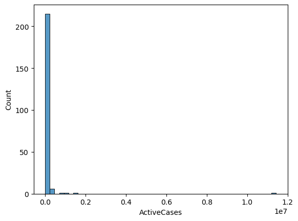

```python
sns.histplot(data=countries_df, x="ActiveCases",bins=50)
```

**NewRecovered**

```python
countries_df['NewRecovered']=countries_df['NewRecovered'].fillna(0)
```

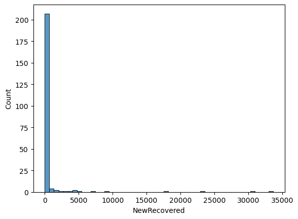

```python
sns.histplot(data=countries_df, x="NewRecovered",bins=50)
```

**Serious,Critical**

```python
countries_df['Serious,Critical']=countries_df['Serious,Critical'].fillna(0)
```

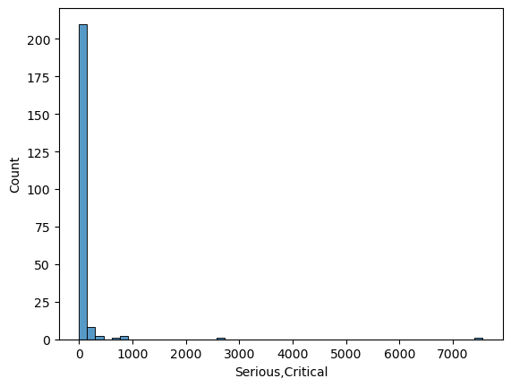

```python
sns.histplot(data=countries_df, x="Serious,Critical",bins=50)
```

**TotalTests**

```python
df = countries_df.loc[countries_df['TotalTests'].isna()]
df
```

|  | # | Country,Other | TotalCases | NewCases | TotalDeaths | NewDeaths | TotalRecovered | NewRecovered | ActiveCases | Serious,Critical | ... | Tests/\n1M pop\n | Population | Continent | 1 Caseevery X ppl | 1 Deathevery X ppl | 1 Testevery X ppl | New Cases/1M pop | New Deaths/1M pop | Active Cases/1M pop | Date |
| --- | --- | --- | --- | --- | --- | --- | --- | --- | --- | --- | --- | --- | --- | --- | --- | --- | --- | --- | --- | --- | --- |
| 38 | 31.0 | DPRK | 4772813 | 0.0 | 74.0 | 0.0 | 4772739.0 | 0.0 | 0.0 | 0.0 | ... | NaN | 25990679.0 | Asia | 5.0 | 351225.0 | NaN | NaN | NaN | NaN | 2023-02-27 |
| 146 | 139.0 | French Polynesia | 77957 | 0.0 | 649.0 | 0.0 | 33500.1 | 0.0 | 43807.9 | 7.0 | ... | NaN | 284164.0 | Australia/Oceania | 4.0 | 438.0 | NaN | NaN | NaN | 154164.0 | 2023-02-27 |
| 158 | 151.0 | Seychelles | 50665 | 0.0 | 172.0 | 0.0 | 50440.0 | 0.0 | 53.0 | 0.0 | ... | NaN | 99426.0 | Africa | 2.0 | 578.0 | NaN | NaN | NaN | 533.0 | 2023-02-27 |
| 164 | 157.0 | Tanzania | 42823 | 0.0 | 846.0 | 0.0 | 200.0 | 0.0 | 41777.0 | 7.0 | ... | NaN | 63298550.0 | Africa | 1478.0 | 74821.0 | NaN | NaN | NaN | 660.0 | 2023-02-27 |
| 180 | 173.0 | Solomon Islands | 24575 | 0.0 | 153.0 | 0.0 | 16357.3 | 0.0 | 8064.7 | 1.0 | ... | NaN | 721159.0 | Australia/Oceania | 29.0 | 4713.0 | NaN | NaN | NaN | 11183.0 | 2023-02-27 |
| 189 | 182.0 | Nicaragua | 18491 | 0.0 | 225.0 | 0.0 | 4225.0 | 0.0 | 14041.0 | 0.0 | ... | NaN | 6779100.0 | North America | 367.0 | 30129.0 | NaN | NaN | NaN | 2071.0 | 2023-02-27 |
| 191 | 184.0 | Tajikistan | 17786 | 0.0 | 125.0 | 0.0 | 17264.0 | 0.0 | 397.0 | 0.0 | ... | NaN | 9957464.0 | Asia | 560.0 | 79660.0 | NaN | NaN | NaN | 40.0 | 2023-02-27 |
| 198 | 191.0 | Marshall Islands | 15598 | 0.0 | 17.0 | 0.0 | 15528.0 | 0.0 | 53.0 | 0.0 | ... | NaN | 60057.0 | Australia/Oceania | 4.0 | 3533.0 | NaN | NaN | NaN | 882.0 | 2023-02-27 |
| 211 | 204.0 | Comoros | 8998 | 0.0 | 161.0 | 0.0 | 8837.0 | 0.0 | 0.0 | 0.0 | ... | NaN | 907419.0 | Africa | 101.0 | 5636.0 | NaN | NaN | NaN | NaN | 2023-02-27 |
| 224 | 217.0 | Kiribati | 5013 | 0.0 | 18.0 | 0.0 | 2703.0 | 0.0 | 2292.0 | 3.0 | ... | NaN | 123419.0 | Australia/Oceania | 25.0 | 6857.0 | NaN | NaN | NaN | 18571.0 | 2023-02-27 |
| 234 | 227.0 | Diamond Princess | 712 | 0.0 | 13.0 | 0.0 | 699.0 | 0.0 | 0.0 | 0.0 | ... | NaN | NaN | NaN | NaN | NaN | NaN | NaN | NaN | NaN | 2023-02-27 |
| 236 | 229.0 | Western Sahara | 10 | 0.0 | 1.0 | 0.0 | 9.0 | 0.0 | 0.0 | 0.0 | ... | NaN | 626161.0 | Africa | 62616.0 | 626161.0 | NaN | NaN | NaN | NaN | 2023-02-27 |
| 237 | 230.0 | MS Zaandam | 9 | 0.0 | 2.0 | 0.0 | 7.0 | 0.0 | 0.0 | 0.0 | ... | NaN | NaN | NaN | NaN | NaN | NaN | NaN | NaN | NaN | 2023-02-27 |

13 rows × 23 columns

It is easy to recognize that all of countries are isolated due to polital conditions, war, poverty or isolation. For instance, `Diamond Princess` and `MS Zaandam` are luxury cruise ships, which had experienced a big virus transmission at the early stage of the Covid-19 pandemic. For further analysis, we would drop these records.

```python
countries_df = countries_df[countries_df['TotalTests'].isna()==False]
```

**Population**

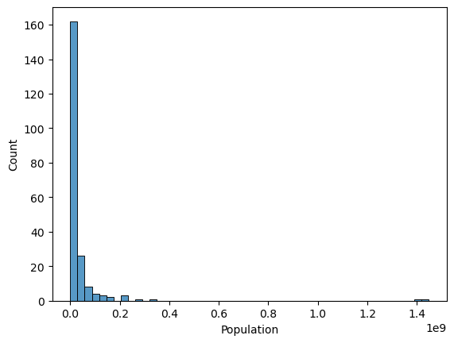

```python
sns.histplot(data=countries_df, x="Population",bins=50)
```

**New Cases/1M pop,New Deaths/1M pop,Active Cases/1M pop**

```python
columns = ['New Cases/1M pop','New Deaths/1M pop','Active Cases/1M pop']
```

```python
countries_df[columns]=countries_df[columns].fillna(0)
```

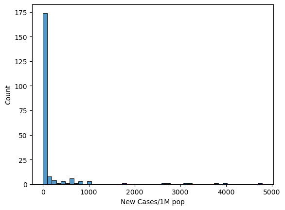

```python
sns.histplot(data=countries_df, x="New Cases/1M pop",bins=50)
```

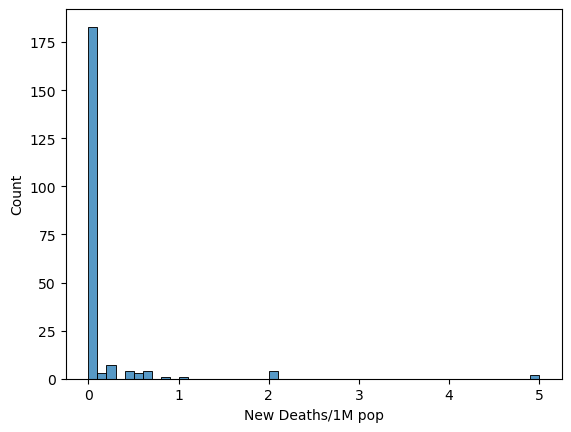

```python
sns.histplot(data=countries_df, x="New Deaths/1M pop",bins=50)
```

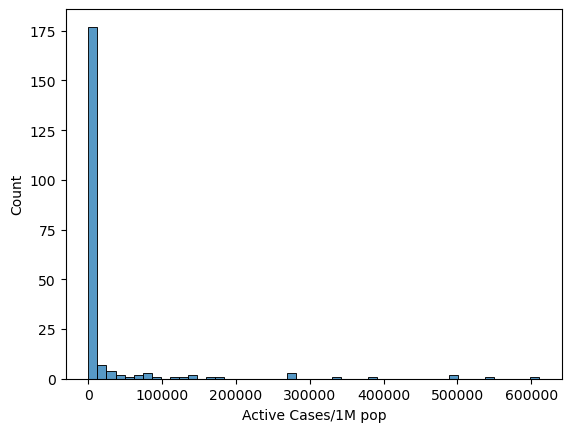

```python
sns.histplot(data=countries_df, x="Active Cases/1M pop",bins=50)
```

It is awesome that there are no missing value now.

```python
df = countries_df.describe().T
df['missing_percentage'] = ((1-df['count']/len(countries_df)) * 100).round(1)
df
```

|  | count | mean | std | min | 25% | 50% | 75% | max | missing_percentage |
| --- | --- | --- | --- | --- | --- | --- | --- | --- | --- |
| # | 212.0 | 1.090896e+02 | 6.385311e+01 | 1.0 | 54.75 | 107.5 | 163.25 | 2.250000e+02 | 0.0 |
| TotalCases | 212.0 | 3.183122e+06 | 9.940184e+06 | 1403.0 | 36815.75 | 269016.5 | 1466371.50 | 1.052768e+08 | 0.0 |
| NewCases | 212.0 | 5.295896e+02 | 2.735008e+03 | 0.0 | 0.00 | 0.0 | 26.00 | 3.297000e+04 | 0.0 |
| TotalDeaths | 212.0 | 3.206255e+04 | 1.090582e+05 | 1.0 | 294.75 | 2869.0 | 16863.75 | 1.145556e+06 | 0.0 |
| NewDeaths | 212.0 | 3.325472e+00 | 1.366466e+01 | 0.0 | 0.00 | 0.0 | 0.00 | 1.390000e+02 | 0.0 |
| TotalRecovered | 212.0 | 3.055399e+06 | 9.616853e+06 | 104.1 | 25486.50 | 242543.5 | 1457077.25 | 1.026544e+08 | 0.0 |
| NewRecovered | 212.0 | 7.421132e+02 | 3.803914e+03 | 0.0 | 0.00 | 0.0 | 13.25 | 3.370600e+04 | 0.0 |
| ActiveCases | 212.0 | 9.566522e+04 | 7.960550e+05 | 0.0 | 83.75 | 1737.0 | 13676.50 | 1.143434e+07 | 0.0 |
| Serious,Critical | 212.0 | 8.182075e+01 | 5.547821e+02 | 0.0 | 0.00 | 2.0 | 20.00 | 7.557000e+03 | 0.0 |
| Tot Cases/1M pop | 212.0 | 1.972533e+05 | 1.970801e+05 | 347.0 | 18548.75 | 128888.5 | 317935.50 | 7.039590e+05 | 0.0 |
| Deaths/1M pop | 212.0 | 1.286778e+03 | 1.285683e+03 | 3.0 | 184.75 | 868.5 | 2062.50 | 6.514000e+03 | 0.0 |
| TotalTests | 212.0 | 3.274787e+07 | 1.184576e+08 | 7850.0 | 355960.00 | 2264975.0 | 13179814.00 | 1.166806e+09 | 0.0 |
| Tests/\n1M pop\n | 212.0 | 2.123620e+06 | 3.635254e+06 | 5091.0 | 187941.50 | 876230.5 | 2396060.75 | 2.330212e+07 | 0.0 |
| Population | 212.0 | 3.696256e+07 | 1.438043e+08 | 4965.0 | 661210.25 | 6706560.0 | 26072509.00 | 1.448471e+09 | 0.0 |
| 1 Caseevery X ppl | 212.0 | 1.276415e+02 | 3.880007e+02 | 1.0 | 3.00 | 8.0 | 54.00 | 2.878000e+03 | 0.0 |
| 1 Deathevery X ppl | 212.0 | 9.632519e+03 | 3.268922e+04 | 154.0 | 485.25 | 1151.0 | 5411.00 | 3.322330e+05 | 0.0 |
| 1 Testevery X ppl | 212.0 | 1.077830e+01 | 2.681219e+01 | 0.0 | 0.00 | 1.0 | 5.00 | 1.960000e+02 | 0.0 |
| New Cases/1M pop | 212.0 | 1.932264e+02 | 6.610292e+02 | 0.0 | 0.00 | 0.0 | 10.00 | 4.790000e+03 | 0.0 |
| New Deaths/1M pop | 212.0 | 1.315094e-01 | 5.670725e-01 | 0.0 | 0.00 | 0.0 | 0.00 | 5.000000e+00 | 0.0 |
| Active Cases/1M pop | 212.0 | 2.603788e+04 | 8.926036e+04 | 0.0 | 39.75 | 411.0 | 2338.00 | 6.111010e+05 | 0.0 |

**Values distribution of Catergorial columns**

```python
pd.set_option('display.max_colwidth', 100) # Để dễ nhìn
pd.set_option('display.max_columns', None) # Để dễ nhìn
# YOUR CODE HERE
cat_data = countries_df.select_dtypes(include=['object'])
value_percentages = cat_data.apply(lambda x: (x.explode().dropna().value_counts(normalize = True)*100).round(1).to_dict())
missing_percentage = cat_data.apply(lambda x: ((1-x.value_counts().sum()/len(countries_df)) * 100).round(1))
num_values = cat_data.apply(lambda x: len(pd.Series(x.unique()).explode().dropna().unique()))
cate_col_info_df = pd.DataFrame({'missing_percentage':missing_percentage,
                                'num_values':num_values,
                                'value_percentages': value_percentages})
cate_col_info_df = cate_col_info_df.T

cate_col_info_df
```

|  | Country,Other | Continent | Date |
| --- | --- | --- | --- |
| missing_percentage | 0.0 | 0.0 | 0.0 |
| num_values | 212 | 6 | 1 |
| value_percentages | {'Kenya': 0.5, 'Timor-Leste': 0.5, 'S. Korea': 0.5, 'Benin': 0.5, 'Norway': 0.5, 'Chile': 0.5, '... | {'Africa': 25.0, 'Asia': 22.6, 'Europe': 22.2, 'North America': 17.9, 'Australia/Oceania': 6.1, ... | {2023-02-27: 100.0} |

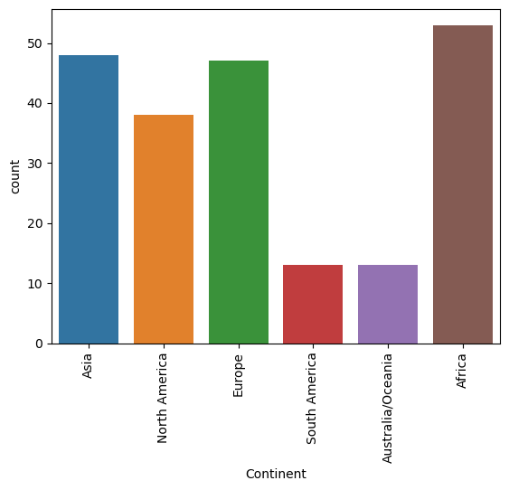

```python
plt.xticks(rotation=90)
sns.countplot(x=countries_df['Continent'])
plt.show()
```

# Question 1: Which attributes contribute to the newcases among countries?

# Continents

```python
continents_df = big_df[(big_df['#'].isna())&((big_df['Country,Other']!='Total:')\
                                             &(big_df['Country,Other']!='\n\n'))&(big_df['Continent']!='All')]
continents_df.head()
```

|  | # | Country,Other | TotalCases | NewCases | TotalDeaths | NewDeaths | TotalRecovered | NewRecovered | ActiveCases | Serious,Critical | Tot Cases/1M pop | Deaths/1M pop | TotalTests | Tests/\n1M pop\n | Population | Continent | 1 Caseevery X ppl | 1 Deathevery X ppl | 1 Testevery X ppl | New Cases/1M pop | New Deaths/1M pop | Active Cases/1M pop | Date |
| --- | --- | --- | --- | --- | --- | --- | --- | --- | --- | --- | --- | --- | --- | --- | --- | --- | --- | --- | --- | --- | --- | --- | --- |
| 0 | NaN | \nAsia\n | 214275435 | 21169.0 | 1536461.0 | 157.0 | 198909142.0 | 28708.0 | 13829832.0 | 15497.0 | NaN | NaN | NaN | NaN | NaN | Asia | NaN | NaN | NaN | NaN | NaN | NaN | 2023-02-27 |
| 1 | NaN | \nNorth America\n | 124580169 | 16947.0 | 1611268.0 | 149.0 | 119787772.0 | 43175.0 | 3181129.0 | 7750.0 | NaN | NaN | NaN | NaN | NaN | North America | NaN | NaN | NaN | NaN | NaN | NaN | 2023-02-27 |
| 2 | NaN | \nEurope\n | 246227059 | 55613.0 | 2016755.0 | 297.0 | 241811330.0 | 45101.0 | 2398974.0 | 6459.0 | NaN | NaN | NaN | NaN | NaN | Europe | NaN | NaN | NaN | NaN | NaN | NaN | 2023-02-27 |
| 3 | NaN | \nSouth America\n | 67991811 | 15796.0 | 1350520.0 | 92.0 | 66251241.0 | 38668.0 | 390050.0 | 10186.0 | NaN | NaN | NaN | NaN | NaN | South America | NaN | NaN | NaN | NaN | NaN | NaN | 2023-02-27 |
| 4 | NaN | \nOceania\n | 13996291 | 1297.0 | 26116.0 | 6.0 | 13834558.0 | 1186.0 | 135617.0 | 64.0 | NaN | NaN | NaN | NaN | NaN | Australia/Oceania | NaN | NaN | NaN | NaN | NaN | NaN | 2023-02-27 |

**Values distribution of Numeric columns**

```python
df = continents_df.describe().T
df['missing_percentage'] = ((1-df['count']/len(continents_df)) * 100).round(1)
df
```

|  | count | mean | std | min | 25% | 50% | 75% | max | missing_percentage |
| --- | --- | --- | --- | --- | --- | --- | --- | --- | --- |
| # | 0.0 | NaN | NaN | NaN | NaN | NaN | NaN | NaN | 100.0 |
| TotalCases | 6.0 | 1.133107e+08 | 1.000085e+08 | 12793643.0 | 27495171.00 | 96285990.0 | 1.918516e+08 | 246227059.0 | 0.0 |
| NewCases | 6.0 | 1.871217e+04 | 1.990258e+04 | 1297.0 | 5037.25 | 16371.5 | 2.011350e+04 | 55613.0 | 0.0 |
| TotalDeaths | 6.0 | 1.133284e+06 | 8.012065e+05 | 26116.0 | 531565.75 | 1443490.5 | 1.592566e+06 | 2016755.0 | 0.0 |
| NewDeaths | 6.0 | 1.175000e+02 | 1.102157e+02 | 4.0 | 27.50 | 120.5 | 1.550000e+02 | 297.0 | 0.0 |
| TotalRecovered | 6.0 | 1.087782e+08 | 9.603848e+07 | 12075067.0 | 26938728.75 | 93019506.5 | 1.791288e+08 | 241811330.0 | 0.0 |
| NewRecovered | 6.0 | 2.622017e+04 | 2.046559e+04 | 483.0 | 8066.50 | 33688.0 | 4.204825e+04 | 45101.0 | 0.0 |
| ActiveCases | 6.0 | 3.399266e+06 | 5.257204e+06 | 135617.0 | 407536.25 | 1429484.5 | 2.985590e+06 | 13829832.0 | 0.0 |
| Serious,Critical | 6.0 | 6.750500e+03 | 5.875042e+03 | 64.0 | 2025.00 | 7104.5 | 9.577000e+03 | 15497.0 | 0.0 |
| Tot Cases/1M pop | 0.0 | NaN | NaN | NaN | NaN | NaN | NaN | NaN | 100.0 |
| Deaths/1M pop | 0.0 | NaN | NaN | NaN | NaN | NaN | NaN | NaN | 100.0 |
| TotalTests | 0.0 | NaN | NaN | NaN | NaN | NaN | NaN | NaN | 100.0 |
| Tests/\n1M pop\n | 0.0 | NaN | NaN | NaN | NaN | NaN | NaN | NaN | 100.0 |
| Population | 0.0 | NaN | NaN | NaN | NaN | NaN | NaN | NaN | 100.0 |
| 1 Caseevery X ppl | 0.0 | NaN | NaN | NaN | NaN | NaN | NaN | NaN | 100.0 |
| 1 Deathevery X ppl | 0.0 | NaN | NaN | NaN | NaN | NaN | NaN | NaN | 100.0 |
| 1 Testevery X ppl | 0.0 | NaN | NaN | NaN | NaN | NaN | NaN | NaN | 100.0 |
| New Cases/1M pop | 0.0 | NaN | NaN | NaN | NaN | NaN | NaN | NaN | 100.0 |
| New Deaths/1M pop | 0.0 | NaN | NaN | NaN | NaN | NaN | NaN | NaN | 100.0 |
| Active Cases/1M pop | 0.0 | NaN | NaN | NaN | NaN | NaN | NaN | NaN | 100.0 |

**Drop unrelevant or null columns**

```python
cols = ['#','Tot\xa0Cases/1M pop', 'Deaths/1M pop', 'TotalTests','Country,Other',\
       'Tests/\n1M pop\n', 'Population', '1 Caseevery X ppl','1 Testevery X ppl',\
       '1 Deathevery X ppl', 'New Cases/1M pop', 'Active Cases/1M pop','New Deaths/1M pop','Date']
# drop unrelevant columns
continents_df =continents_df.drop(columns=cols,axis=1)
continents_df
```

|  | TotalCases | NewCases | TotalDeaths | NewDeaths | TotalRecovered | NewRecovered | ActiveCases | Serious,Critical | Continent |
| --- | --- | --- | --- | --- | --- | --- | --- | --- | --- |
| 0 | 214275435 | 21169.0 | 1536461.0 | 157.0 | 198909142.0 | 28708.0 | 13829832.0 | 15497.0 | Asia |
| 1 | 124580169 | 16947.0 | 1611268.0 | 149.0 | 119787772.0 | 43175.0 | 3181129.0 | 7750.0 | North America |
| 2 | 246227059 | 55613.0 | 2016755.0 | 297.0 | 241811330.0 | 45101.0 | 2398974.0 | 6459.0 | Europe |
| 3 | 67991811 | 15796.0 | 1350520.0 | 92.0 | 66251241.0 | 38668.0 | 390050.0 | 10186.0 | South America |
| 4 | 13996291 | 1297.0 | 26116.0 | 6.0 | 13834558.0 | 1186.0 | 135617.0 | 64.0 | Australia/Oceania |
| 5 | 12793643 | 1451.0 | 258581.0 | 4.0 | 12075067.0 | 483.0 | 459995.0 | 547.0 | Africa |

**TotalTests**

```python
df=countries_df.groupby(['Continent']).TotalTests.sum().reset_index()
continents_df = continents_df.merge(df,on='Continent',how='left')
```

**Values distribution of Catergorial columns**

```python
pd.set_option('display.max_colwidth', 100) # Để dễ nhìn
pd.set_option('display.max_columns', None) # Để dễ nhìn
# YOUR CODE HERE
cat_data = continents_df.select_dtypes(include=['object'])
value_percentages = cat_data.apply(lambda x: (x.explode().dropna().value_counts(normalize = True)*100).round(1).to_dict())
missing_percentage = cat_data.apply(lambda x: ((1-x.value_counts().sum()/len(continents_df)) * 100).round(1))
num_values = cat_data.apply(lambda x: len(pd.Series(x.unique()).explode().dropna().unique()))
cate_col_info_df = pd.DataFrame({'missing_percentage':missing_percentage,
                                'num_values':num_values,
                                'value_percentages': value_percentages})
cate_col_info_df = cate_col_info_df.T

cate_col_info_df
```

|  | Continent |
| --- | --- |
| missing_percentage | 0.0 |
| num_values | 6 |
| value_percentages | {'Asia': 16.7, 'Africa': 16.7, 'Europe': 16.7, 'Australia/Oceania': 16.7, 'North America': 16.7,... |

# Question 2. What is the different picture of covid pandemic between continents?

**Step summary:**

1. **General situation analysis ('TotalCases','TotalRecovered','TotalTests','TotalDeaths')**
2. **Background analysis (Population)**
3. **Current situation analysis ('NewCases','NewDeaths','NewRecovered','Serious,Critical')**
4. **Activecase analysis**
5. **Conclusion**

### General situation analysis

[figure not shown]

```python
df = continents_df[['Continent','TotalCases','TotalRecovered','TotalTests','TotalDeaths']]

plt.figure(figsize=(12, 10))
parallel_coordinates(df,'Continent', colormap=plt.get_cmap("Set2"))
plt.title('Parallel coodinate show the grades\' difference among 5 students')
plt.xticks(rotation=90)
plt.show()
```

**TotalCases**

```python
df = countries_df.groupby('Continent').TotalCases.sum()
df
```

```
Continent
Africa                12688981
Asia                 209484836
Australia/Oceania     13869550
Europe               246227030
North America        124561678
South America         67989881
Name: TotalCases, dtype: int64
```

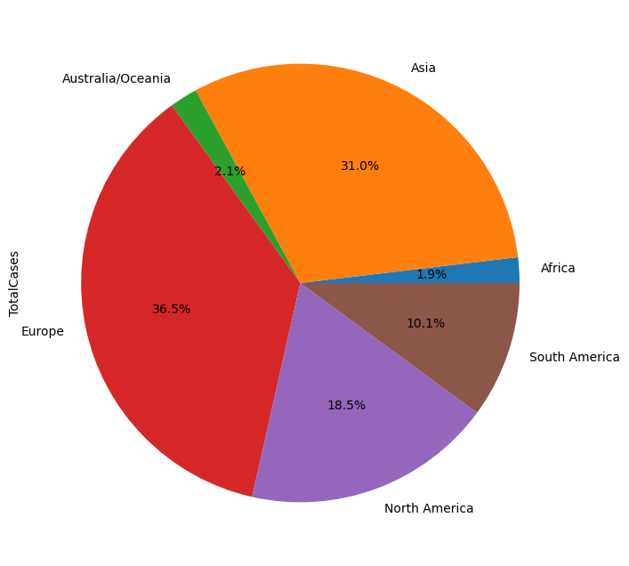

```python
plt.figure(figsize=(10, 8))
df.plot.pie(autopct="%.1f%%");
```

**TotalDeaths**

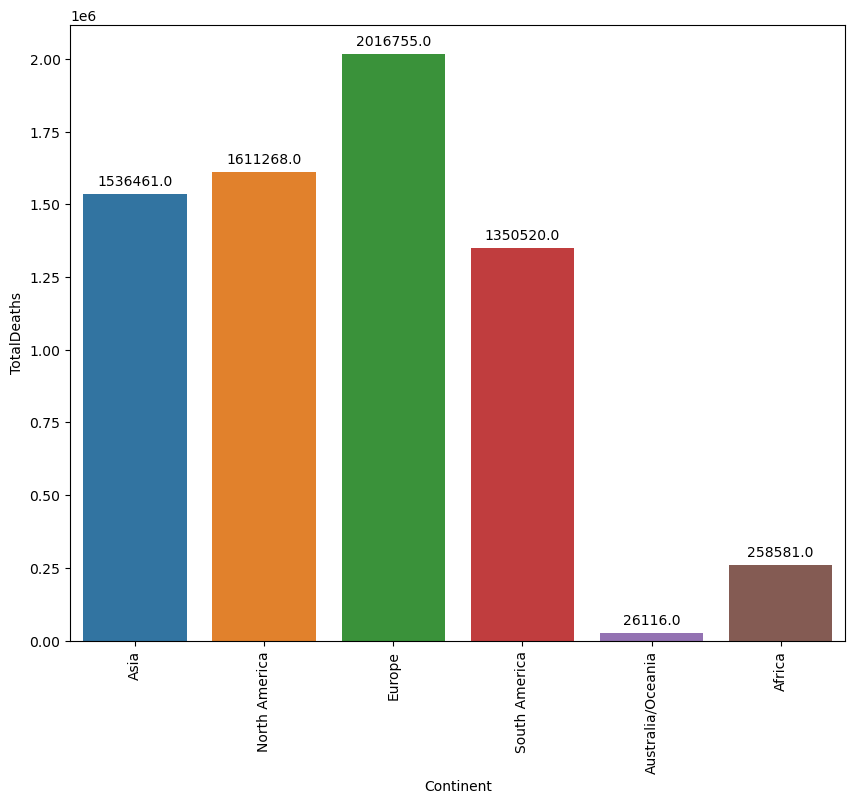

```python
# bar plot
plt.figure(figsize=(10, 8))
splot = sns.barplot(x='Continent', y='TotalDeaths', data=continents_df)
for p in splot.patches:
    splot.annotate(format(p.get_height(), '.1f'),
                   (p.get_x() + p.get_width() / 2., p.get_height()),
                   ha = 'center', va = 'center',
                   xytext = (0, 9),
                   textcoords = 'offset points')
plt.xticks(rotation=90)
plt.show()
```

**NewDeaths**

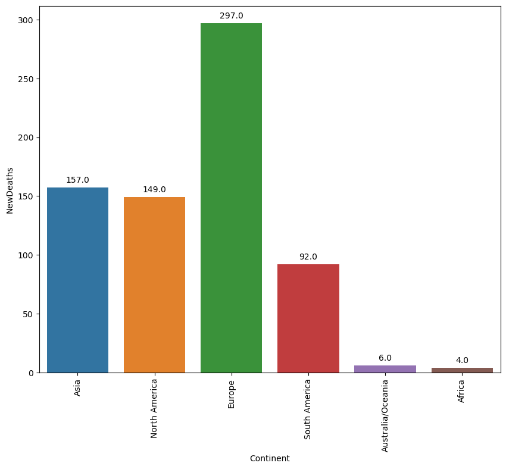

```python
# bar plot
plt.figure(figsize=(10, 8))
splot = sns.barplot(x='Continent', y='NewDeaths', data=continents_df)
for p in splot.patches:
    splot.annotate(format(p.get_height(), '.1f'),
                   (p.get_x() + p.get_width() / 2., p.get_height()),
                   ha = 'center', va = 'center',
                   xytext = (0, 9),
                   textcoords = 'offset points')
plt.xticks(rotation=90)
plt.show()
```

**TotalRecovered**

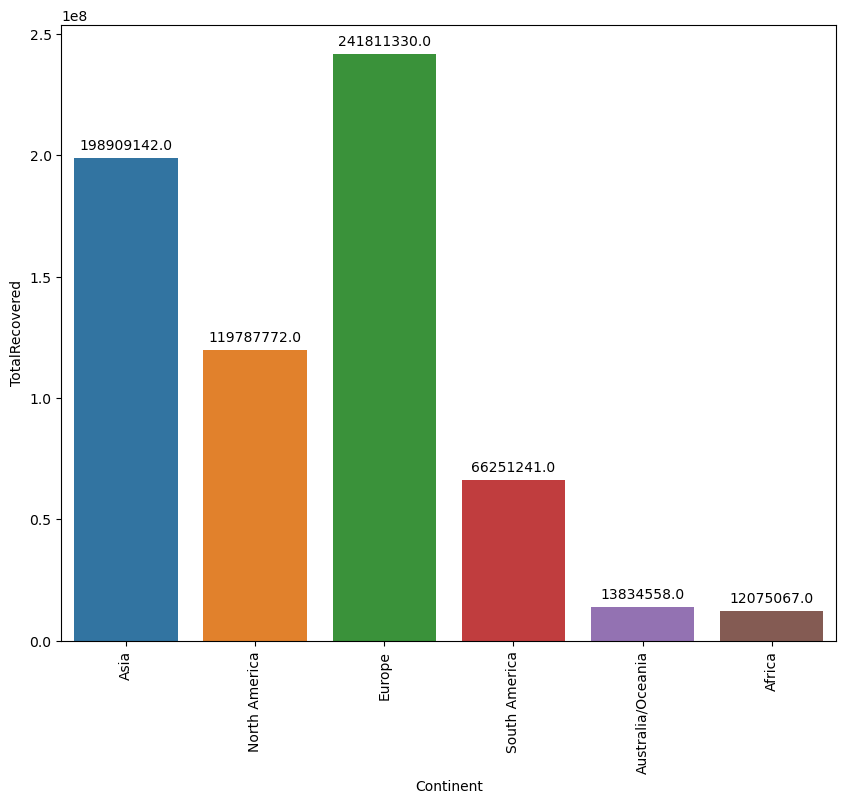

```python
# bar plot
plt.figure(figsize=(10, 8))
splot = sns.barplot(x='Continent', y='TotalRecovered', data=continents_df)
for p in splot.patches:
    splot.annotate(format(p.get_height(), '.1f'),
                   (p.get_x() + p.get_width() / 2., p.get_height()),
                   ha = 'center', va = 'center',
                   xytext = (0, 9),
                   textcoords = 'offset points')
plt.xticks(rotation=90)
plt.show()
```

**NewRecovered**

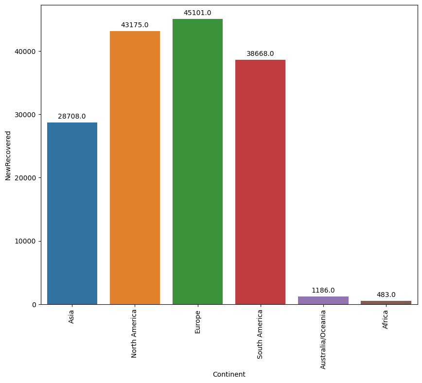

```python
# bar plot
plt.figure(figsize=(10, 8))
splot = sns.barplot(x='Continent', y='NewRecovered', data=continents_df)
for p in splot.patches:
    splot.annotate(format(p.get_height(), '.1f'),
                   (p.get_x() + p.get_width() / 2., p.get_height()),
                   ha = 'center', va = 'center',
                   xytext = (0, 9),
                   textcoords = 'offset points')
plt.xticks(rotation=90)
plt.show()
```

**ActiveCases**

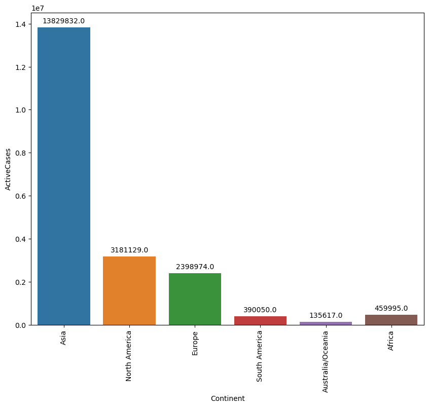

```python
# bar plot
plt.figure(figsize=(10, 8))
splot = sns.barplot(x='Continent', y='ActiveCases', data=continents_df)
for p in splot.patches:
    splot.annotate(format(p.get_height(), '.1f'),
                   (p.get_x() + p.get_width() / 2., p.get_height()),
                   ha = 'center', va = 'center',
                   xytext = (0, 9),
                   textcoords = 'offset points')
plt.xticks(rotation=90)
plt.show()
```

**Serious,Critical**

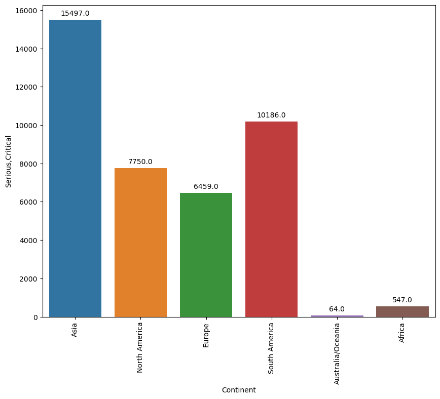

```python
# bar plot
plt.figure(figsize=(10, 8))
splot = sns.barplot(x='Continent', y='Serious,Critical', data=continents_df)
for p in splot.patches:
    splot.annotate(format(p.get_height(), '.1f'),
                   (p.get_x() + p.get_width() / 2., p.get_height()),
                   ha = 'center', va = 'center',
                   xytext = (0, 9),
                   textcoords = 'offset points')
plt.xticks(rotation=90)
plt.show()
```

**Population**

```python
countries_df = big_df.dropna(subset=['#'])
countries_df.head()
```

|  | # | Country,Other | TotalCases | NewCases | TotalDeaths | NewDeaths | TotalRecovered | NewRecovered | ActiveCases | Serious,Critical | Tot Cases/1M pop | Deaths/1M pop | TotalTests | Tests/\n1M pop\n | Population | Continent | 1 Caseevery X ppl | 1 Deathevery X ppl | 1 Testevery X ppl | New Cases/1M pop | New Deaths/1M pop | Active Cases/1M pop | Date |
| --- | --- | --- | --- | --- | --- | --- | --- | --- | --- | --- | --- | --- | --- | --- | --- | --- | --- | --- | --- | --- | --- | --- | --- |
| 8 | 1.0 | China | 503302 | NaN | 5272.0 | NaN | 379053.0 | NaN | 118977.0 | 7557.0 | 347.0 | 4.0 | 1.600000e+08 | 110461.0 | 1.448471e+09 | Asia | 2878.0 | 274748.0 | 9.0 | NaN | NaN | 82.0 | 2023-02-27 |
| 9 | 2.0 | USA | 105276823 | 6894.0 | 1145556.0 | 70.0 | 102654350.0 | 33706.0 | 1476917.0 | 2586.0 | 314442.0 | 3422.0 | 1.166806e+09 | 3485028.0 | 3.348053e+08 | North America | 3.0 | 292.0 | 0.0 | 210.0 | 0.2 | 4411.0 | 2023-02-27 |
| 10 | 3.0 | India | 44686371 | 169.0 | 530771.0 | 1.0 | 44153343.0 | 140.0 | 2257.0 | NaN | 31768.0 | 377.0 | 9.185351e+08 | 653003.0 | 1.406632e+09 | Asia | 31.0 | 2650.0 | 2.0 | 1.0 | NaN | 2.0 | 2023-02-27 |
| 11 | 4.0 | France | 39616580 | 841.0 | 164929.0 | 52.0 | 39383240.0 | 4999.0 | 68411.0 | 869.0 | 604054.0 | 2515.0 | 2.714902e+08 | 4139547.0 | 6.558452e+07 | Europe | 2.0 | 398.0 | 0.0 | 130.0 | 0.8 | 1043.0 | 2023-02-27 |
| 12 | 5.0 | Germany | 38144033 | 32970.0 | 167951.0 | 139.0 | 37679400.0 | 17900.0 | 296682.0 | NaN | 454726.0 | 2002.0 | 1.223324e+08 | 1458359.0 | 8.388360e+07 | Europe | 2.0 | 499.0 | 1.0 | 3930.0 | 2.0 | 3537.0 | 2023-02-27 |

```python
df=countries_df.groupby(['Continent']).Population.sum().reset_index()
df
```

|  | Continent | Population |
| --- | --- | --- |
| 0 | Africa | 1.406729e+09 |
| 1 | Asia | 4.711357e+09 |
| 2 | Australia/Oceania | 4.347041e+07 |
| 3 | Europe | 7.475438e+08 |
| 4 | North America | 5.981409e+08 |
| 5 | South America | 4.376944e+08 |

```python
continents_df = continents_df.merge(df,on='Continent',how='left')
```

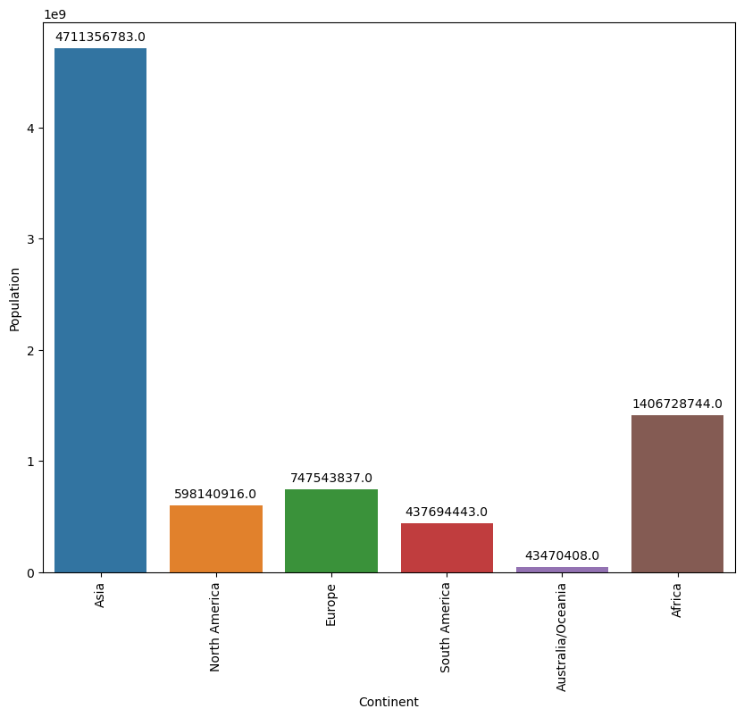

```python
# bar plot
plt.figure(figsize=(10, 8))
splot = sns.barplot(x='Continent', y='Population', data=continents_df)
for p in splot.patches:
    splot.annotate(format(p.get_height(), '.1f'),
                   (p.get_x() + p.get_width() / 2., p.get_height()),
                   ha = 'center', va = 'center',
                   xytext = (0, 9),
                   textcoords = 'offset points')
plt.xticks(rotation=90)
plt.show()
```

**TotalTests**

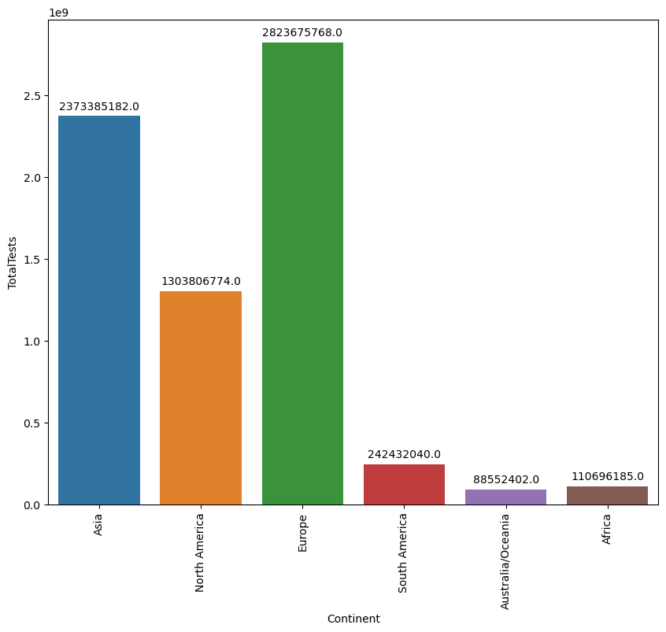

```python
# bar plot
plt.figure(figsize=(10, 8))
splot = sns.barplot(x='Continent', y='TotalTests', data=continents_df)
for p in splot.patches:
    splot.annotate(format(p.get_height(), '.1f'),
                   (p.get_x() + p.get_width() / 2., p.get_height()),
                   ha = 'center', va = 'center',
                   xytext = (0, 9),
                   textcoords = 'offset points')
plt.xticks(rotation=90)
plt.show()
```

**Current situation analysis**

[figure not shown]

```python
df = continents_df[['Continent','NewCases','NewDeaths','NewRecovered','Serious,Critical']]
plt.figure(figsize=(12, 10))
parallel_coordinates(df,'Continent', colormap=plt.get_cmap("Set2"))
plt.title('Parallel coodinate show the grades\' difference among 5 students')
plt.xticks(rotation=90)
plt.show()
```

**NewCases**

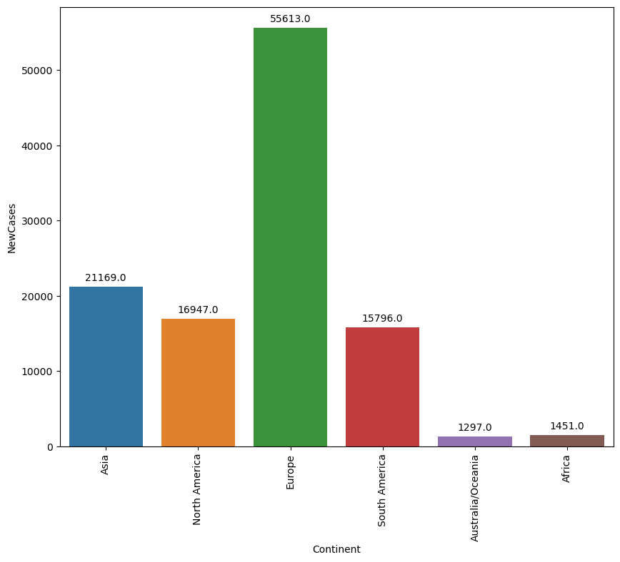

```python
# bar plot
plt.figure(figsize=(10, 8))
splot = sns.barplot(x='Continent', y='NewCases', data=continents_df)
for p in splot.patches:
    splot.annotate(format(p.get_height(), '.1f'),
                   (p.get_x() + p.get_width() / 2., p.get_height()),
                   ha = 'center', va = 'center',
                   xytext = (0, 9),
                   textcoords = 'offset points')
plt.xticks(rotation=90)
plt.show()
```